# Assignment 10: Predictive Modeling - Part 1

*How to do it?*:

- Open the Rmarkdown file of this assignment (link) in Rstudio.
- Right under each **question**, insert a code chunk (you can use the hotkey `Ctrl + Alt + I` to add a code chunk) and code the solution for the question.
- `Knit` the rmarkdown file (hotkey: `Ctrl + Alt + K`) to export an html.
- Publish the html file to your Githiub Page.

*Submission*: Submit the link on Github of the assignment to Canvas

1. Use the `Adult Census Income` dataset. We will predict the income (whether or not it is more than 50k or not) of an adult. Import the dataset. Partition the data into 80% training and 20% testing.

```r
library(tidyverse)
df <- read_csv('adult_census.csv')
```

```r
#take out some columns
df <- df %>% select(-fnlwgt, -marital.status, -occupation, -relationship, -capital.gain, -capital.loss)

#set the target variable
df <- df %>% rename(target=income)
```

```r
#changing character variables to factors
df <- df %>%
  mutate(target = as.factor(target),
         workclass = as.factor(workclass),
         race = as.factor(race),
         sex = as.factor(sex),
         education = as.factor(education),
         native.country = as.factor(native.country)
         )

#drop NA values
df = drop_na(df)
```

```r
#install.packages("caret")
library(caret)
set.seed(2023)
splitIndex <- createDataPartition(df$target, p = .80,
                                  list = FALSE)
df_train <- df[ splitIndex,]
df_test <- df[-splitIndex,]
```

2. Practice Decision Tree. Do the follows:
- Use `rpart` package, create a decision tree with maximum depth of 3.

```r
#install.packages("rpart")
library(rpart)

decision_tree <- rpart(target ~ ., data = df_train,
                 control = rpart.control(maxdepth = 3))
```

- Calculate the accuracy of the model on the testing data. Notice that the positive outcome here is not `1` but `>50K` or `<50K`.

```r
pred <- predict(decision_tree, df_test, type = "class")
#Evaluate the predictions
cm <- confusionMatrix(data = pred, reference = df_test$target, positive = ">50K")
cm$overall[1]
```

```
##  Accuracy
## 0.8042842
```

- Plot the tree

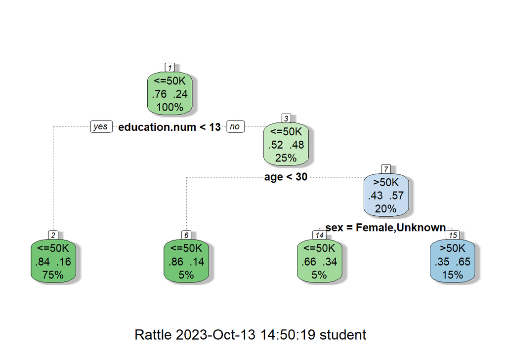

```r
#install.packages("rattle")
library(rattle)
fancyRpartPlot(decision_tree)
```

- Plot the variable importance by the tree

```r
decision_tree$variable.importance
```

```
##  education.num      education            age            sex native.country
##     1004.23735     1002.60163      378.21161      187.43691       15.17954
```

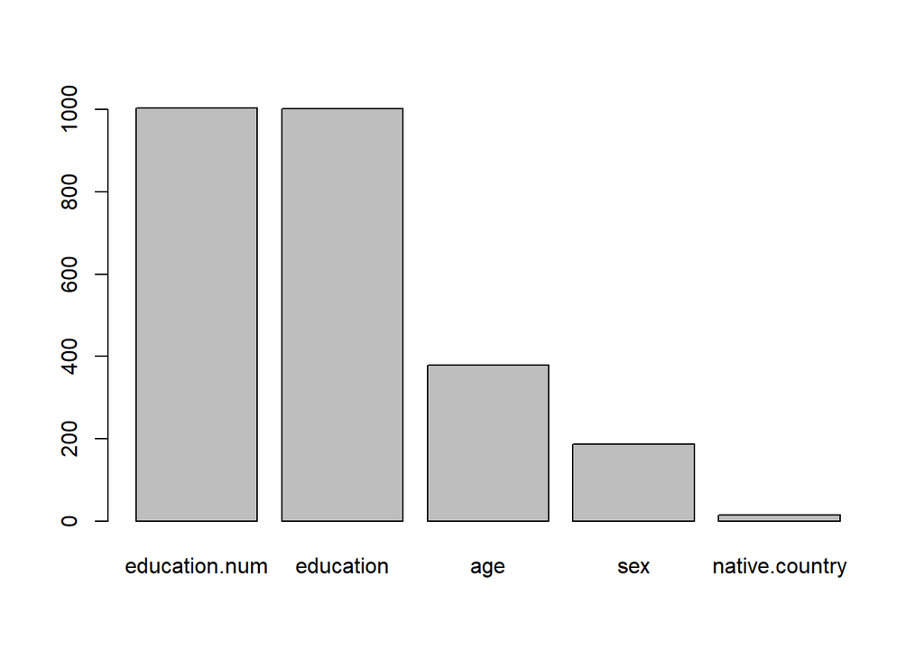

```r
barplot(decision_tree$variable.importance)
```

3. Create 3 more trees and compare the testing accuracy of these trees, which tree give the highest testing accuracy.

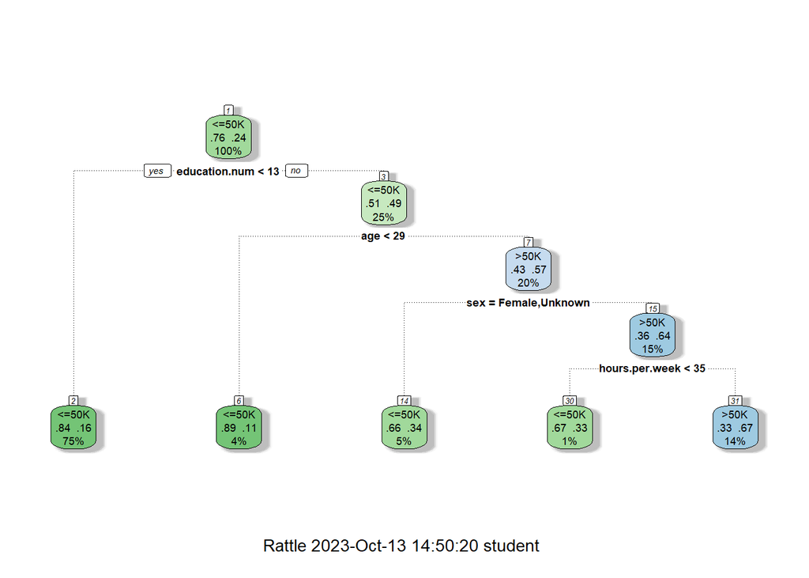

```r
set.seed(2010)
splitIndex <- createDataPartition(df$target, p = .80,
                                  list = FALSE)
df_train <- df[ splitIndex,]
df_test <- df[-splitIndex,]

tree1 <- rpart(target ~ ., data = df_train,
                 control = rpart.control(maxdepth = 11))

fancyRpartPlot(tree1)
```

```r
#accuracy of tree1
pred <- predict(tree1, df_test, type = "class")
#Evaluate the predictions
cm <- confusionMatrix(data = pred, reference = df_test$target, positive = ">50K")
cm$overall[1]
```

```
##  Accuracy
## 0.8022808
```

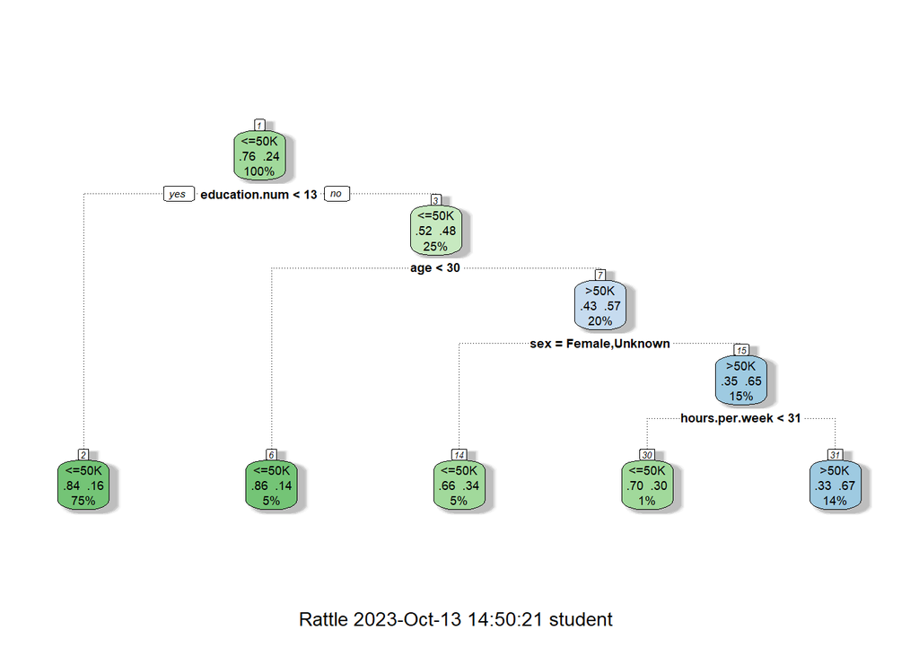

```r
set.seed(1000)
splitIndex <- createDataPartition(df$target, p = .80,
                                  list = FALSE)
df_train <- df[ splitIndex,]
df_test <- df[-splitIndex,]

tree2 <- rpart(target ~ ., data = df_train,
                 control = rpart.control(maxdepth = 30))

fancyRpartPlot(tree2)
```

```r
#accuracy of tree2
pred <- predict(tree2, df_test, type = "class")
#Evaluate the predictions
cm <- confusionMatrix(data = pred, reference = df_test$target, positive = ">50K")
cm$overall[1]
```

```
##  Accuracy
## 0.8087533
```

```r
#Of the trees trained, tree 2 yields the highest accuracy.
```

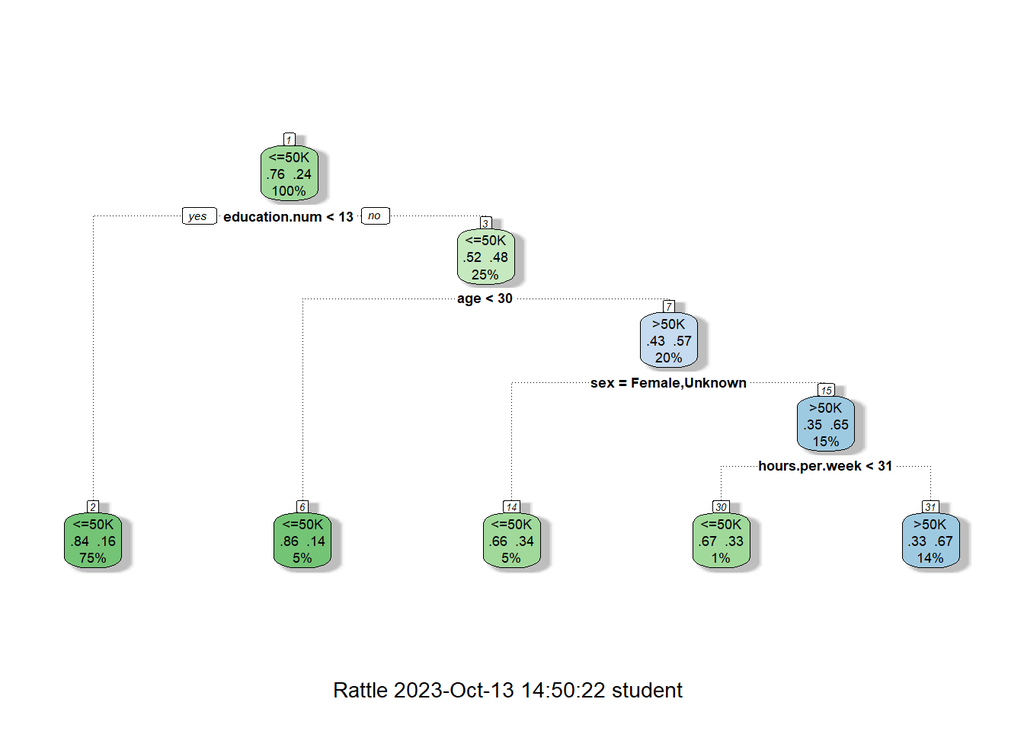

```r
set.seed(1780)
splitIndex <- createDataPartition(df$target, p = .80,
                                  list = FALSE)
df_train <- df[ splitIndex,]
df_test <- df[-splitIndex,]

tree3 <- rpart(target ~ ., data = df_train,
                 control = rpart.control(maxdepth = 6))

fancyRpartPlot(tree3)
```

```r
#accuracy of tree3
pred <- predict(tree3, df_test, type = "class")
#Evaluate the predictions
cm <- confusionMatrix(data = pred, reference = df_test$target, positive = ">50K")
cm$overall[1]
```

```
##  Accuracy
## 0.8062876
```

4. Practice Random Forest. Do the follows:
- Use `randomForest` package, create a random forest of 1000 trees.

```r
#install.packages("randomForest")
library(randomForest)
forest_model = randomForest(target ~ ., data=df_train, ntree = 1000)
pred <- predict(forest_model, df_test, type = "class")
```

- Calculate the accuracy of the model on the testing data.

```r
cm <- confusionMatrix(data = pred, reference = df_test$target, positive = ">50K")
cm$overall[1]
```

```
##  Accuracy
## 0.8126059
```

```r
importance(forest_model)
```

```
##                MeanDecreaseGini
## age                   1217.6614
## workclass              344.5304
## education              720.4612
## education.num          622.9557
## race                   127.2805
## sex                    375.5017
## hours.per.week         658.3298
## native.country         281.1860
```

5. Create 3 more forests and compare the testing accuracy of these forests, which forest give the highest testing accuracy.

```r
forest_model1 = randomForest(target ~ ., data=df_train, ntree = 2023)
pred <- predict(forest_model1, df_test, type = "class")

cm <- confusionMatrix(data = pred, reference = df_test$target, positive = ">50K")
cm$overall[1]
```

```
##  Accuracy
## 0.8124518
```

```r
#of the forest trained, forest_model1 yields the highest testing accuracy
```

```r
forest_model2 = randomForest(target ~ ., data=df_train, ntree = 50)
pred <- predict(forest_model2, df_test, type = "class")

cm <- confusionMatrix(data = pred, reference = df_test$target, positive = ">50K", "<50K")
cm$overall[1]
```

```
##  Accuracy
## 0.8110649
```

```r
forest_model3 = randomForest(target ~ ., data=df_train, ntree = 4000)
pred <- predict(forest_model3, df_test, type = "class")

cm <- confusionMatrix(data = pred, reference = df_test$target, positive = ">50K")
cm$overall[1]
```

```
##  Accuracy
## 0.8116813
```

6. What is the best model (in term of testing accuracy) among all models (including trees and forests) you have trained?

```r
library(randomForest)
forest_model = randomForest(target ~ ., data=df_train, ntree = 1000)
pred <- predict(forest_model, df_test, type = "class")


#Of all models, I've trained, this model yields the highest testing accuracy. Accuracy :0.8126059
```